# Cibersortx Cell Fraction Analysis

2026-03-13

```r
library(tidyverse)
library(glue)
library(readxl)
library(RColorBrewer)
library(cowplot)
library(SummarizedExperiment)
library(DirichletReg)
```

```r
set.seed(2026)
```

# Import data

```r
load("../data/raw/rnaseq_hersh.Rdata")

subgroup_palette <- c(
  "EZH2"      = "#E69F00",
  "TET2-bi"   = "#56B4E9",
  "-7"        = "#009E73",
  "STAG2"     = "#CC79A7",
  "del5q-IB"  = "#F0E442",
  "SF3B1-IB"  = "#0072B2",
  "Complex"   = "#D55E00",
  "MDS-LB"    = "#999999",
  "MDS-IB1"   = "grey40",
  "MDS-IB2"   = "black"
)

subgroups <- names(subgroup_palette)

who_palette <- c(
  "MDS-5q"    = "#F0E442",
  "MDS-SF3B1" = "#0072B2",
  "MDS-TP53"  = "#D55E00",
  "MDS-LB"    = "#999999",
  "MDS-IB1"   = "grey40",
  "MDS-IB2"   = "black"
)

who_levels <- names(who_palette)

sample_metadata <- colData(se_hersh) |>
  as.data.frame() |>
  select(-SEX, -AGE, -Exam_Array) |>
  rename_with(str_to_snake) |>
  rownames_to_column("sample") |>
  select(sample, who, bm_blast, wbc, hb, plt, ipssm, sub_group) |>
  mutate(who = factor(who, levels = who_levels)) |>
  mutate(sub_group = factor(sub_group, levels = subgroups))

types_palette <- c(
                      "hspc" = "#984EA3",
          "dc_monocytic_gmp" = "#4DAF4A",
  "megakaryocytic_erythroid" = "#E41A1C",
      "early_lymphoid_bcell" = "#377EB8",
                      "t_nk" = "#FF7F00"
)

types <- names(types_palette)

fractions <- "../data/cibersortx_results/CIBERSORTx_Job2_Results.csv" |>
  read_csv(show_col_types = FALSE) |>
  select(sample = Mixture, all_of(types))
```

# Exploratory plots

Barplots, with rows ordered by hierarchical clustering.

```r
fractions_matrix <- fractions |>
  column_to_rownames("sample") |>
  as.matrix()

clust <- fractions_matrix |>
  dist() |>
  hclust()

hclust_order <- clust$order |>
  set_names(clust$labels)

base_barplot <- sample_metadata |>
  filter(!is.na(sub_group)) |>
  select(sample, sub_group, who) |>
  inner_join(fractions, by = "sample") |>
  mutate(
    hclust_order = hclust_order[sample],
    sample = fct_reorder(sample, hclust_order)
    ) |>
  pivot_longer(all_of(types), names_to = "cell_type", values_to = "fraction") |>
  mutate(cell_type = factor(cell_type, levels = types)) |>
  ggplot(aes(y = sample, x = fraction, fill = cell_type)) +
  geom_col(color = NA) +
  scale_x_reverse() +
  scale_fill_manual(values = types_palette) +
  theme(
    axis.text.y = element_blank(),
    axis.ticks.y = element_blank(),
    strip.text.y = element_text(angle = 0),
    strip.clip = "off",
    plot.title = element_text(hjust = 1),
    plot.title.position = "plot",
    legend.position = "bottom",
    axis.title.y = element_blank()
    )
```

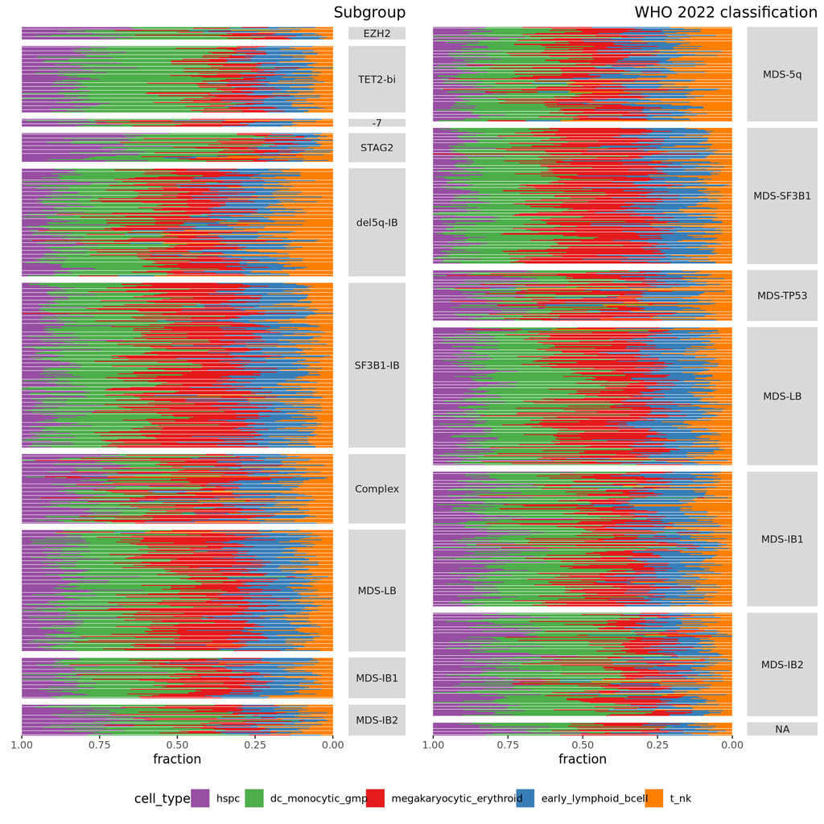

```r
stacked_barplot_by_subgroup <- base_barplot +
  facet_grid(sub_group ~ . , scales = "free", space = "free") +
  ggtitle("Subgroup")

stacked_barplot_by_who <- base_barplot +
  facet_grid(who ~ . , scales = "free", space = "free") +
  ggtitle("WHO 2022 classification")

stacked_barplot <- plot_grid(
  # Plots
  plot_grid(
    stacked_barplot_by_subgroup + theme(legend.position = "none"),
    stacked_barplot_by_who  + theme(legend.position = "none"),
    ncol = 2
  ),
  # Legend
  get_legend(stacked_barplot_by_subgroup),
  ncol = 1, rel_heights = c(15, 1)
)

stacked_barplot
```

```r
ggsave(
  "../figures/stacked_barplot_cell_fractions.pdf",
  stacked_barplot,
  width = 10,
  height = 10,
  units = "in"
  )
```

[output not shown]

# PCAs of the cell fractions

```r
# I don't think fractions should be scaled

pca <- prcomp(fractions_matrix)

rotation <- pca$rotation |>
  as.data.frame() |>
  rownames_to_column("cell_type") |>
  mutate(cell_type = str_replace_all(cell_type, "_", "\n"))

importances <- summary(pca)$importance[2,] |>
  signif(2)

base_pca <- pca$x |>
  as.data.frame() |>
  rownames_to_column("sample") |>
  left_join(sample_metadata, by = "sample") |>
  ggplot(aes(x = PC1, y = PC2)) +
  geom_segment(
    data = rotation,
    aes(x = 0, y = 0, xend = PC1, yend = PC2)
  ) +
  geom_label(
    data = rotation,
    size = 3,
    aes(x = PC1, y = PC2, label = cell_type)
  ) +
  xlab(glue("PC1 ({importances[1]})")) +
  ylab(glue("PC2 ({importances[2]})")) +
  theme_minimal() +
  theme(
    axis.text = element_blank(),
    )
```

## Colored by subgroup

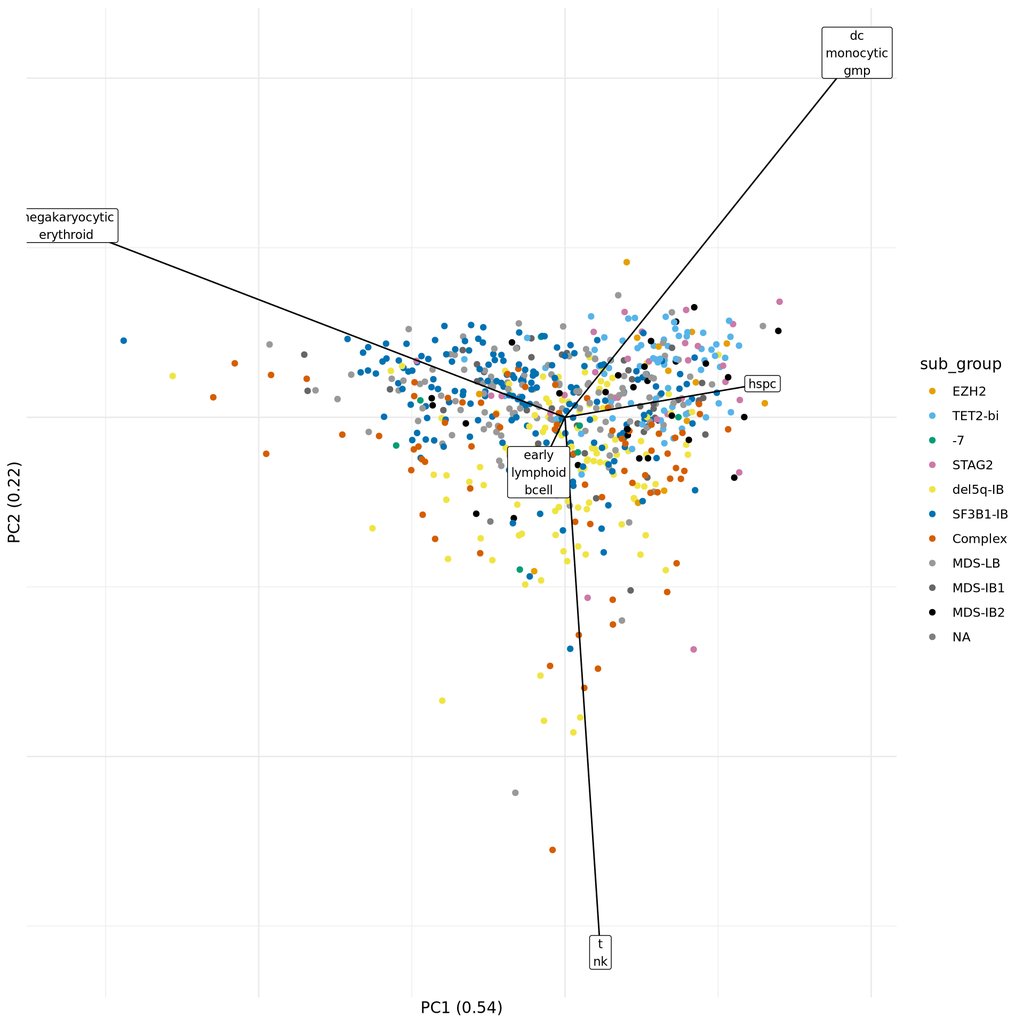

```r
pca_by_subgroup <- base_pca

pca_by_subgroup$layers <- c(
  geom_point(aes(color = sub_group)),
  pca_by_subgroup$layers
)

pca_by_subgroup <- pca_by_subgroup +
  scale_color_manual(values = subgroup_palette)

pca_by_subgroup
```

```r
ggsave(
  "../figures/pca_cell_fractions_by_subgroup.pdf",
  pca_by_subgroup,
  width = 10,
  height = 10,
  units = "in"
  )
```

- SF3B1 are enriched in erythroid. This is expected and acts as a sanity check.
- del5qs are enriched in lymphocytes. These have an inflammatory biology so it checks out.

## Highlight of newly defined groups

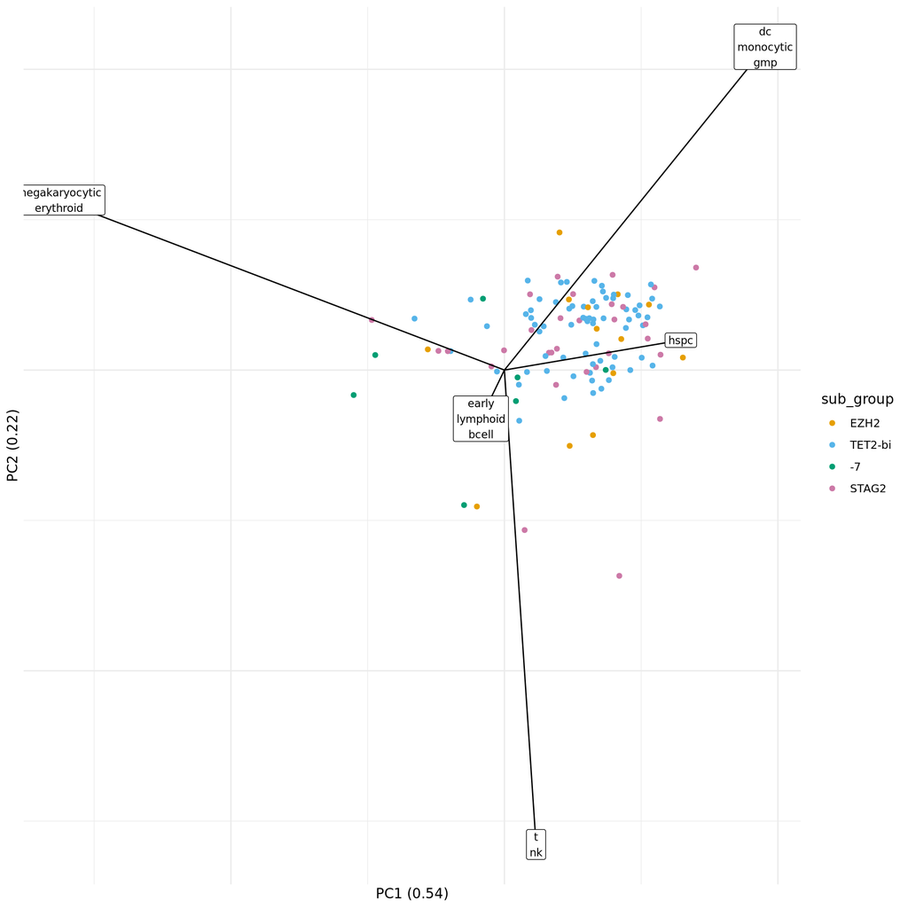

```r
pca_by_subgroup_hl <- base_pca

pca_by_subgroup_hl$layers <- c(
  geom_point(
    data = pca_by_subgroup_hl$data |>
      filter(sub_group %in% c("TET2-bi", "STAG2","-7", "EZH2")),
    aes(color = sub_group),
    ),
  pca_by_subgroup_hl$layers
)

pca_by_subgroup_hl <- pca_by_subgroup_hl +
  scale_color_manual(values = subgroup_palette) +
  scale_alpha_manual(values = 0:1)

pca_by_subgroup_hl
```

Focusing on the newly defined groups:

## Colored by WHO 2022

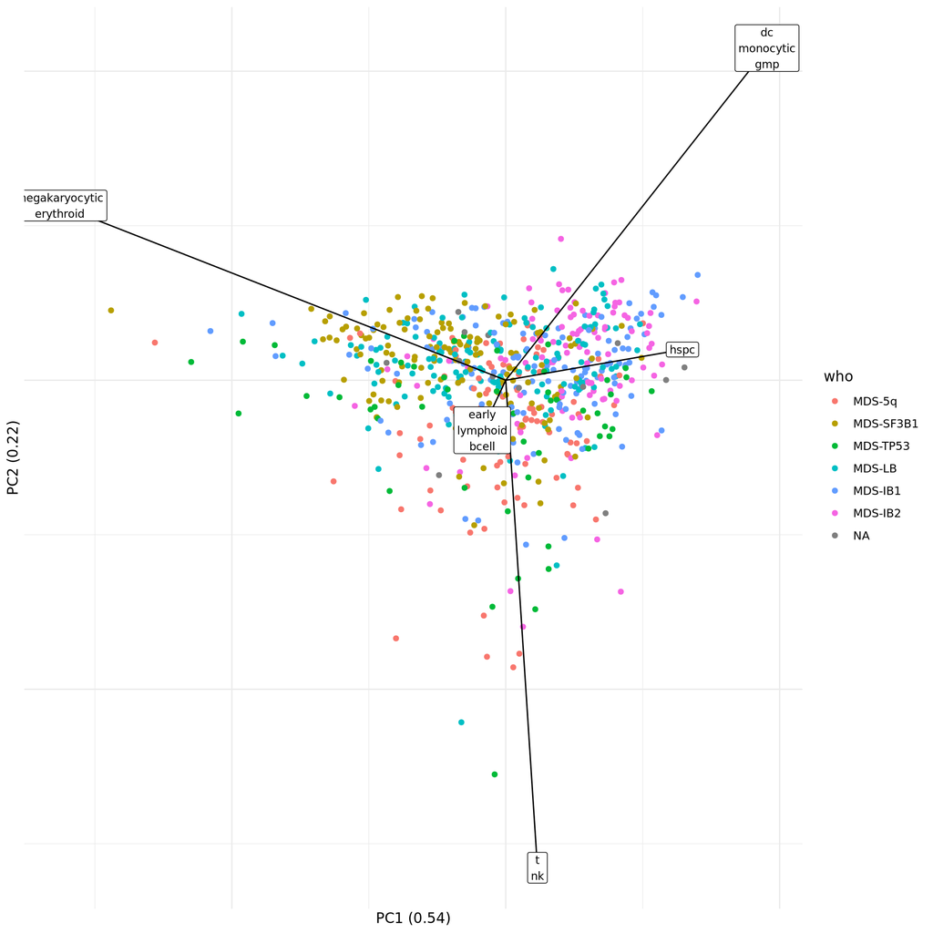

```r
pca_by_who <- base_pca
pca_by_who$layers <- c(geom_point(aes(color = who)), pca_by_who$layers)
pca_by_who <- pca_by_who + scale_fill_brewer(palette = "Set3")
pca_by_who
```

```r
ggsave(
  "../figures/pca_cell_fractions_by_who.pdf",
  pca_by_who,
  width = 10,
  height = 10,
  units = "in"
  )
```

# Boxplots of cell fractions

```r
boxplots_df <- fractions |>
  inner_join(sample_metadata, by = "sample") |>
  pivot_longer(all_of(types), values_to = "fraction", names_to = "cell_type") |>
  pivot_longer(c(sub_group, who), names_to = "classification", values_to = "group") |>
  mutate(
    cell_type = factor(cell_type, levels = types),
    group = factor(group, levels = c(subgroups, "MDS-5q", "MDS-SF3B1", "MDS-TP53"))
    )
```

## Grouped by cell type

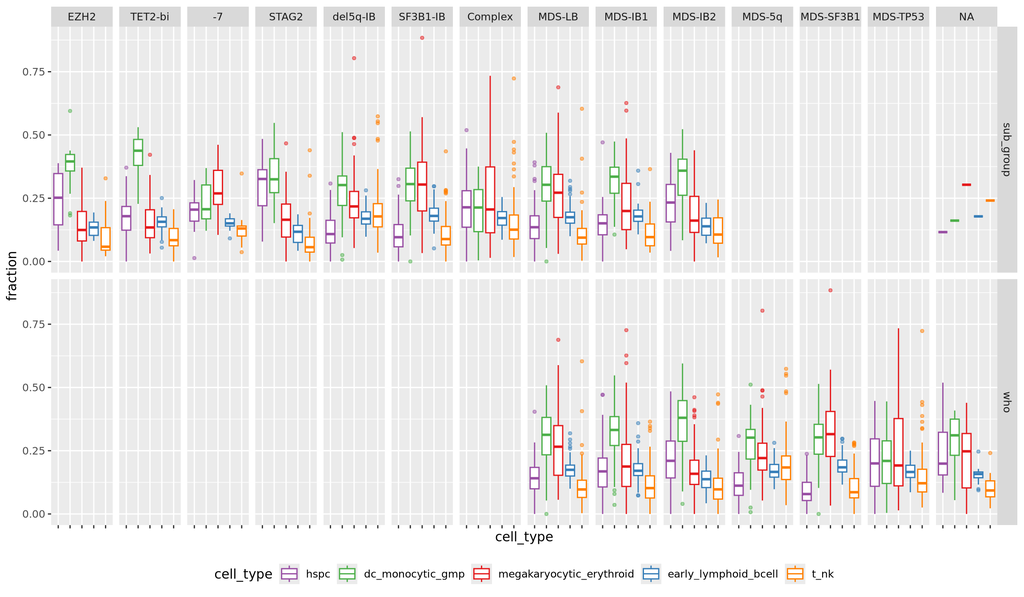

```r
boxplot_by_type <- boxplots_df |>
  ggplot(aes(x = cell_type, color = cell_type, y = fraction)) +
  geom_boxplot(outlier.alpha = 0.5, outlier.size = 1) +
  facet_grid(classification ~ group) +
  scale_color_manual(values = types_palette) +
  theme(axis.text.x = element_blank(), legend.position = "bottom")

boxplot_by_type
```

```r
ggsave(
  "../figures/boxplot_by_type_cell_fractions.pdf",
  boxplot_by_type,
  width = 12,
  height = 7,
  units = "in"
  )
```

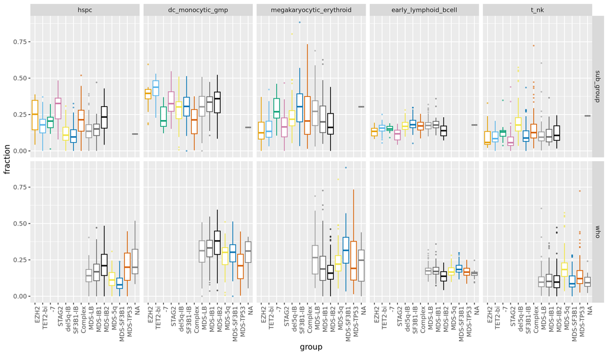

```r
boxplot_by_group <- fractions |>
  inner_join(sample_metadata, by = "sample") |>
  pivot_longer(all_of(types), values_to = "fraction", names_to = "cell_type") |>
  pivot_longer(c(sub_group, who), names_to = "classification", values_to = "group") |>
  mutate(
    cell_type = factor(cell_type, levels = types),
    group = factor(group, levels = c(subgroups, "MDS-5q", "MDS-SF3B1", "MDS-TP53"))
    ) |>
  ggplot(aes(x = group, y = fraction, color = group)) +
  scale_color_manual(values = c(
    subgroup_palette,
    "MDS-5q" = "#F0E442",
    "MDS-SF3B1" = "#0072B2",
    "MDS-TP53" = "#D55E00")
    ) +
  facet_grid(classification ~ cell_type, scales = "free", space = "free") +
  geom_boxplot(outlier.alpha = 0.5, outlier.size = 0.5) +
  theme(
    axis.text.x = element_text(angle = 90, hjust = 1),
    legend.position = "none",
  )

boxplot_by_group
```

```r
ggsave(
  "../figures/boxplot_by_group_cell_fractions.pdf",
  boxplot_by_group,
  width = 12,
  height = 7,
  units = "in"
  )
```

# Dirichlet regression

First we evaluate if there are zeroes

```r
sum(fractions_matrix == 0)
```

```
## [1] 22
```

There are, so we add a pseudocount

```r
pseudocount <- unique(sort(as.double(fractions_matrix)))[2]
pseudoc_matrix <- fractions_matrix + pseudocount
pseudoc_matrix <- pseudoc_matrix / rowSums(pseudoc_matrix)
```

## Subgroup

We fit the model cell fractions ~ subgroup

We set `MDS-LB` as the baseline group

```r
dr_df <- as.data.frame(pseudoc_matrix) |>
  rownames_to_column("sample") |>
  inner_join(select(sample_metadata, sample, sub_group), by = "sample") |>
  select(sub_group, all_of(types)) |>
  mutate(sub_group = fct_relevel(sub_group, "MDS-LB"))

Y <- DR_data(select(dr_df, -sub_group))

fit <- DirichReg(Y ~ sub_group, data = dr_df)

s <- summary(fit)

s
```

```
## Call:
## DirichReg(formula = Y ~ sub_group, data = dr_df)
##
## Standardized Residuals:
##                               Min       1Q   Median      3Q     Max
## hspc                      -2.3817  -0.6382   0.0052  0.6670  4.2228
## dc_monocytic_gmp          -3.0363  -0.6341   0.1029  0.6711  2.4652
## megakaryocytic_erythroid  -2.6004  -0.8310  -0.0127  0.9248  6.5689
## early_lymphoid_bcell      -1.7336  -0.4916  -0.2223  0.0792  1.7823
## t_nk                      -1.9003  -0.6838  -0.2917  0.3697  7.1858
##
## ------------------------------------------------------------------
## Beta-Coefficients for variable no. 1: hspc
##                   Estimate Std. Error z value Pr(>|z|)
## (Intercept)        1.09294    0.07244  15.088  < 2e-16 ***
## sub_groupEZH2      0.20683    0.23591   0.877  0.38065
## sub_groupTET2-bi   0.47265    0.11886   3.976    7e-05 ***
## sub_group-7        0.07699    0.29524   0.261  0.79426
## sub_groupSTAG2     0.38075    0.16380   2.324  0.02010 *
## sub_groupdel5q-IB -0.13140    0.10610  -1.238  0.21554
## sub_groupSF3B1-IB -0.31045    0.09660  -3.214  0.00131 **
## sub_groupComplex  -0.16849    0.12206  -1.380  0.16746
## sub_groupMDS-IB1  -0.04871    0.14545  -0.335  0.73772
## sub_groupMDS-IB2   0.16471    0.16048   1.026  0.30473
## ------------------------------------------------------------------
## Beta-Coefficients for variable no. 2: dc_monocytic_gmp
##                    Estimate Std. Error z value Pr(>|z|)
## (Intercept)        1.844211   0.068986  26.733  < 2e-16 ***
## sub_groupEZH2     -0.079548   0.229134  -0.347    0.728
## sub_groupTET2-bi   0.698951   0.113511   6.158 7.39e-10 ***
## sub_group-7       -0.370192   0.288570  -1.283    0.200
## sub_groupSTAG2    -0.194652   0.161012  -1.209    0.227
## sub_groupdel5q-IB -0.021821   0.100505  -0.217    0.828
## sub_groupSF3B1-IB -0.001814   0.091016  -0.020    0.984
## sub_groupComplex  -0.958069   0.120284  -7.965 1.65e-15 ***
## sub_groupMDS-IB1   0.019763   0.138071   0.143    0.886
## sub_groupMDS-IB2  -0.254340   0.156277  -1.627    0.104
## ------------------------------------------------------------------
## Beta-Coefficients for variable no. 3: megakaryocytic_erythroid
##                   Estimate Std. Error z value Pr(>|z|)
```

[output cut: 29 more lines]

```
## sub_group-7        0.05634    0.30026   0.188 0.851172
## sub_groupSTAG2    -0.67070    0.17758  -3.777 0.000159 ***
## sub_groupdel5q-IB  0.55727    0.10485   5.315 1.07e-07 ***
## sub_groupSF3B1-IB -0.02514    0.09715  -0.259 0.795799
## sub_groupComplex  -0.20743    0.12424  -1.670 0.095018 .
## sub_groupMDS-IB1  -0.04083    0.14772  -0.276 0.782249
## sub_groupMDS-IB2  -0.27744    0.16760  -1.655 0.097852 .
## ------------------------------------------------------------------
## Significance codes: 0 '***' 0.001 '**' 0.01 '*' 0.05 '.' 0.1 ' ' 1
##
## Log-likelihood: 3329 on 50 df (222 BFGS + 2 NR Iterations)
## AIC: -6558, BIC: -6333
## Number of Observations: 675
## Link: Log
## Parametrization: common
```

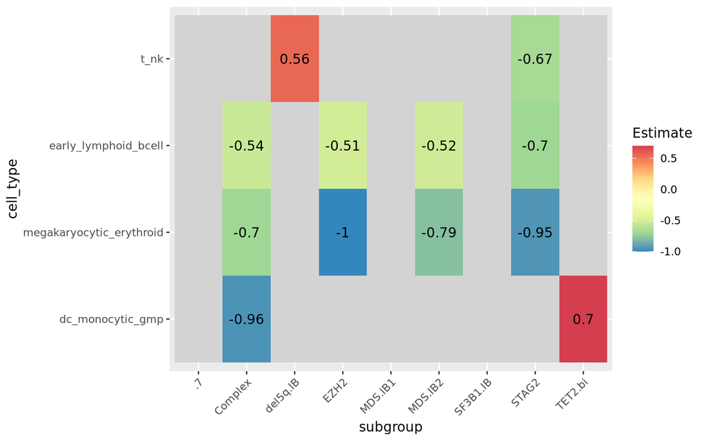

```r
s$coef.mat |>
  as.data.frame() |>
  split(unlist(map2(s$n.vars, s$varnames, ~rep(.y, .x)))) |>
  bind_rows(.id = "cell_type") |>
  rownames_to_column("subgroup") |>
  mutate(
    cell_type = factor(cell_type, levels = types),
    subgroup = str_match(subgroup, "sub_group(.+)\\.\\d$")[,2],
    Estimate = if_else(`Pr(>|z|)` < 0.05, Estimate, NA)
    ) |>
  filter(subgroup != "X") |>
  ggplot(aes(x = subgroup, y = cell_type, fill = Estimate)) +
  geom_tile() +
  geom_text(aes(label = signif(Estimate, 2))) +
  scale_fill_distiller(palette = "Spectral", na.value = "lightgrey") +
  theme(axis.text.x = element_text(angle = 45, hjust = 1))
```

To compute confidence intervals for the predictions, we run 100 bootstraps of the modelling

```r
n_bootstraps <- 100

bootstraps_results <- 1:n_bootstraps %>%
  map(~ {
    idx <- sample(1:nrow(dr_df), nrow(dr_df), replace = TRUE)
    df_boot <- dr_df[idx, ]
    Y_boot <- DR_data(df_boot %>% select(-sub_group))
    fit <- DirichReg(Y_boot ~ sub_group, data = df_boot)
    prediction <- predict(fit, tibble(sub_group = subgroups))
    rownames(prediction) <- subgroups
    colnames(prediction) <- types

    prediction |>
      as.data.frame() |>
      rownames_to_column("sub_group")

  }, .progress = "calculating_bootstraps") |>
  bind_rows(.id = "bootstrap") |>
  pivot_longer(all_of(types), names_to = "cell_type", values_to = "fraction") |>
  group_by(sub_group, cell_type) |>
  summarise(
    median = median(fraction),
    lower_ci = quantile(fraction, 0.025),
    upper_ci = quantile(fraction, 0.975),
    groups = "drop_last"
    )  |>
  write_csv(bootstrap_results_file)
```

```r
bootstraps_results <- read_csv(bootstrap_results_file) |>
  mutate(
    cell_type = factor(cell_type, levels = types),
    sub_group = factor(sub_group, levels = subgroups)
    )
```

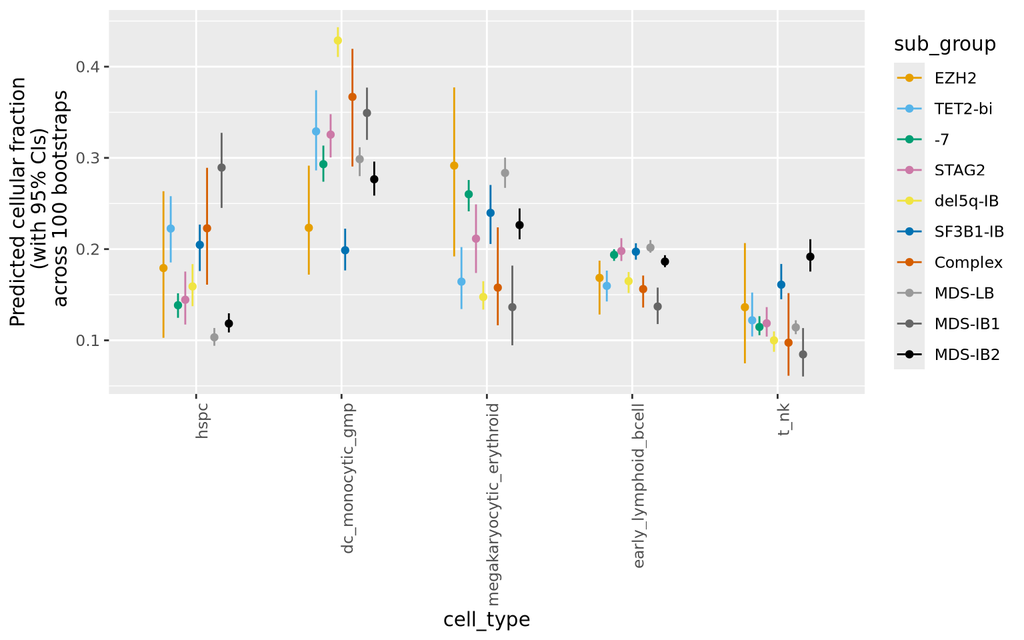

```r
dodge <- 0.5

bootstraps_results |>
  ggplot() +
  geom_point(
    aes(x = cell_type, y = median, color = sub_group),
    position = position_dodge(width = dodge)
    ) +
  geom_segment(
    aes(x = cell_type, y = lower_ci, yend = upper_ci, color = sub_group),
    position = position_dodge(width = dodge)
  ) +
  scale_color_manual(values = subgroup_palette) +
  ylab("Predicted cellular fraction\n (with 95% CIs)\n across 100 bootstraps") +
  theme(axis.text.x = element_text(angle = 90, hjust = 1))
```

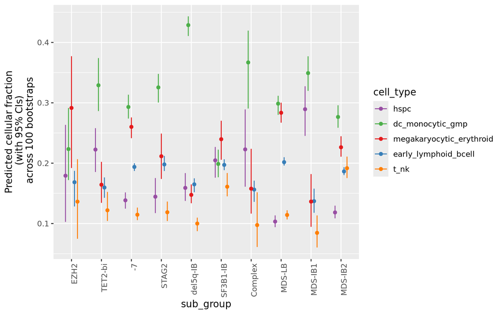

```r
dodge <- 0.5

bootstraps_results |>
  ggplot() +
  geom_point(
    aes(x = sub_group, y = median, color = cell_type),
    position = position_dodge(width = dodge)
    ) +
  geom_segment(
    aes(x = sub_group, y = lower_ci, yend = upper_ci, color = cell_type),
    position = position_dodge(width = dodge)
  ) +
  scale_color_manual(values = types_palette) +
  ylab("Predicted cellular fraction\n (with 95% CIs)\n across 100 bootstraps") +
  theme(axis.text.x = element_text(angle = 90, hjust = 1))
```

## WHO 2022

We use `MDS-LB` as the baseline group

```r
dr_df <- as.data.frame(pseudoc_matrix) |>
  rownames_to_column("sample") |>
  left_join(select(sample_metadata, sample, who), by = "sample") |>
  select(who, all_of(types)) |>
  mutate(who = fct_relevel(who, "MDS-LB"))

Y <- DR_data(select(dr_df, -who))

fit <- DirichReg(Y ~ who, data = dr_df)

s <- summary(fit)
```

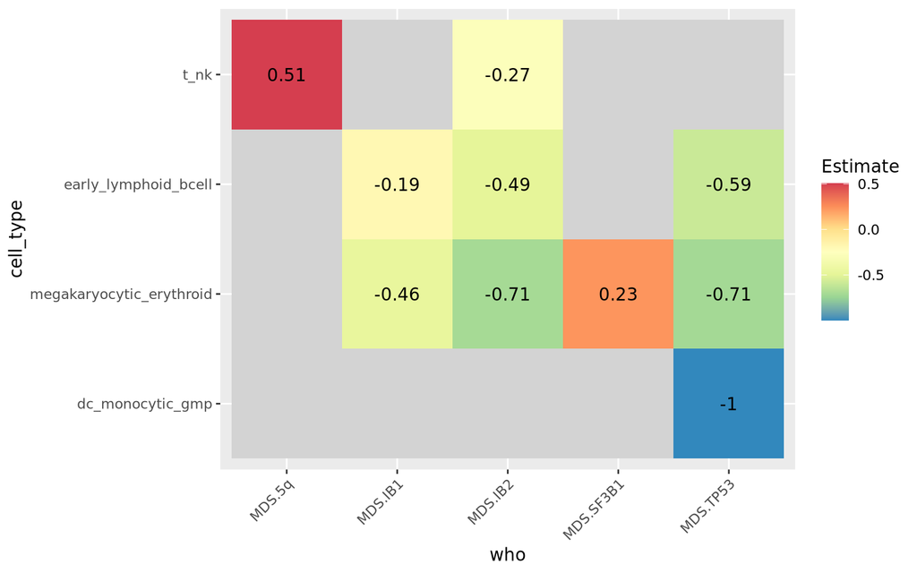

```r
s$coef.mat |>
  as.data.frame() |>
  split(unlist(map2(s$n.vars, s$varnames, ~rep(.y, .x)))) |>
  bind_rows(.id = "cell_type") |>
  rownames_to_column("who") |>
  mutate(
    cell_type = factor(cell_type, levels = types),
    who = str_match(who, "who(.+)\\.\\d$")[,2],
    Estimate = if_else(`Pr(>|z|)` < 0.05, Estimate, NA)
    ) |>
  filter(who != "X") |>
  ggplot(aes(x = who, y = cell_type, fill = Estimate)) +
  geom_tile() +
  geom_text(aes(label = signif(Estimate, 2))) +
  scale_fill_distiller(palette = "Spectral", na.value = "lightgrey") +
  theme(axis.text.x = element_text(angle = 45, hjust = 1))
```

## Hematogram

We predict the hematological clinical variables, scaling them first with z-score

```r
hemato_vars <- c("bm_blast","wbc","hb","plt")

hematogram <- sample_metadata |>
  select(sample, all_of(hemato_vars)) |>
  drop_na() |>
  column_to_rownames("sample") |>
  as.matrix() |>
  scale() |>
  as.data.frame() |>
  rownames_to_column("sample")

dr_df <- as.data.frame(pseudoc_matrix) |>
  rownames_to_column("sample") |>
  left_join(hematogram, by = "sample")

Y <- DR_data(select(dr_df, -all_of(hemato_vars), -sample))

fit <- DirichReg(
  as.formula(glue("Y ~ {paste(hemato_vars, collapse = ' + ')}")),
  data = dr_df
  )

s <- summary(fit)

s
```

```
## Call:
## DirichReg(formula = as.formula(glue("Y ~ {paste(hemato_vars, collapse = ' +
## ')}")), data = dr_df)
##
## Standardized Residuals:
##                               Min       1Q   Median      3Q     Max
## hspc                      -2.3452  -0.6561  -0.0455  0.6580  5.8932
## dc_monocytic_gmp          -3.2551  -0.5583   0.1423  0.6743  2.3448
## megakaryocytic_erythroid  -2.3166  -0.8400  -0.0274  0.8702  7.0695
## early_lymphoid_bcell      -1.3293  -0.4777  -0.2170  0.0483  1.9182
## t_nk                      -1.7341  -0.7561  -0.2481  0.4213  7.8018
##
## ------------------------------------------------------------------
## Beta-Coefficients for variable no. 1: hspc
##              Estimate Std. Error z value Pr(>|z|)
## (Intercept)  0.950429   0.032620  29.136  < 2e-16 ***
## bm_blast     0.191521   0.032968   5.809 6.27e-09 ***
## wbc          0.105949   0.031450   3.369 0.000755 ***
## hb           0.013275   0.032317   0.411 0.681227
## plt         -0.001901   0.039915  -0.048 0.962018
## ------------------------------------------------------------------
## Beta-Coefficients for variable no. 2: dc_monocytic_gmp
##             Estimate Std. Error z value Pr(>|z|)
## (Intercept)  1.68347    0.03101  54.290  < 2e-16 ***
## bm_blast     0.03213    0.03176   1.012  0.31165
## wbc          0.09028    0.03373   2.676  0.00744 **
## hb           0.15937    0.02897   5.501 3.79e-08 ***
## plt          0.08217    0.03052   2.693  0.00709 **
## ------------------------------------------------------------------
## Beta-Coefficients for variable no. 3: megakaryocytic_erythroid
##             Estimate Std. Error z value Pr(>|z|)
## (Intercept)  1.39982    0.03157  44.345  < 2e-16 ***
## bm_blast    -0.20480    0.03441  -5.952 2.64e-09 ***
## wbc         -0.07883    0.04934  -1.598   0.1101
## hb           0.01343    0.03290   0.408   0.6830
## plt          0.07853    0.02637   2.978   0.0029 **
## ------------------------------------------------------------------
## Beta-Coefficients for variable no. 4: early_lymphoid_bcell
##             Estimate Std. Error z value Pr(>|z|)
## (Intercept)  1.22191    0.03193  38.268  < 2e-16 ***
## bm_blast    -0.09914    0.03368  -2.943  0.00325 **
## wbc          0.07322    0.03066   2.388  0.01693 *
## hb           0.09557    0.03267   2.925  0.00344 **
## plt          0.06022    0.03061   1.968  0.04911 *
## ------------------------------------------------------------------
## Beta-Coefficients for variable no. 5: t_nk
##             Estimate Std. Error z value Pr(>|z|)
## (Intercept)  0.82962    0.03293  25.193  < 2e-16 ***
## bm_blast    -0.03330    0.03521  -0.946 0.344307
## wbc          0.09812    0.02853   3.440 0.000582 ***
## hb           0.06350    0.03366   1.886 0.059228 .
## plt          0.13988    0.03003   4.659 3.18e-06 ***
## ------------------------------------------------------------------
## Significance codes: 0 '***' 0.001 '**' 0.01 '*' 0.05 '.' 0.1 ' ' 1
##
## Log-likelihood: 3030 on 25 df (166 BFGS + 2 NR Iterations)
## AIC: -6011, BIC: -5899
## Number of Observations: 642
## Link: Log
## Parametrization: common
```

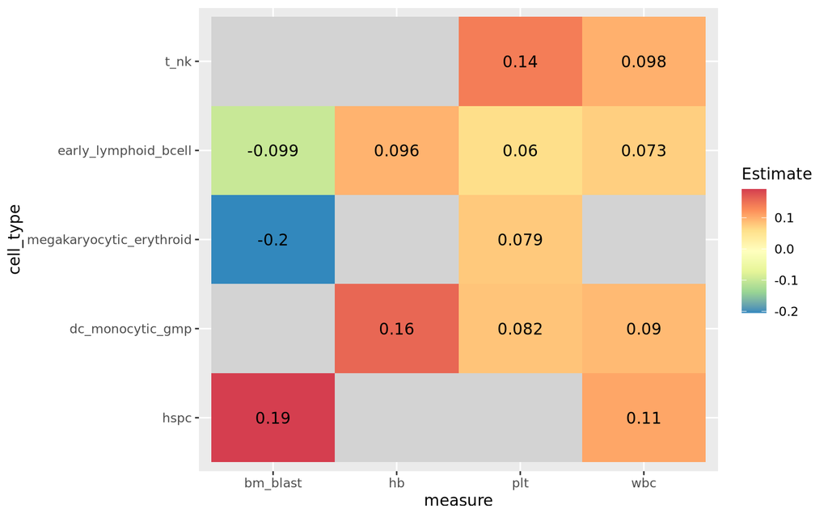

```r
s$coef.mat |>
  as.data.frame() |>
  split(unlist(map2(s$n.vars, s$varnames, ~rep(.y, .x)))) |>
  bind_rows(.id = "cell_type") |>
  rownames_to_column("measure") |>
  mutate(
    cell_type = factor(cell_type, levels = types),
    measure = str_split_i(measure, "\\.", 1),
    Estimate = if_else(`Pr(>|z|)` < 0.05, Estimate, NA)
    ) |>
  filter(measure != "X") |>
  ggplot(aes(x = measure, y = cell_type, fill = Estimate)) +
  geom_tile() +
  geom_text(aes(label = signif(Estimate, 2))) +
  scale_fill_distiller(palette = "Spectral", na.value = "lightgrey")
```

Coefficients of each cell type vs clinical measurements. Only significant (pvalue < 0.05) estimates are shown.